# R Notebook

```r
library(tidyverse)
library(infer)
library(janitor)
```

Explore the dataset

| name | genus | vore | order | conservation | sleep_total | sleep_rem | sleep_cycle | awake | brainwt | bodywt |
| --- | --- | --- | --- | --- | --- | --- | --- | --- | --- | --- |
| Cheetah | Acinonyx | carni | Carnivora | lc | 12.1 | NA | NA | 11.9 | NA | 50.000 |
| Owl monkey | Aotus | omni | Primates | NA | 17.0 | 1.8 | NA | 7.0 | 0.01550 | 0.480 |
| Mountain beaver | Aplodontia | herbi | Rodentia | nt | 14.4 | 2.4 | NA | 9.6 | NA | 1.350 |
| Greater short-tailed shrew | Blarina | omni | Soricomorpha | lc | 14.9 | 2.3 | 0.1333333 | 9.1 | 0.00029 | 0.019 |
| Cow | Bos | herbi | Artiodactyla | domesticated | 4.0 | 0.7 | 0.6666667 | 20.0 | 0.42300 | 600.000 |
| Three-toed sloth | Bradypus | herbi | Pilosa | NA | 14.4 | 2.2 | 0.7666667 | 9.6 | NA | 3.850 |

Jabberwockies sleep for around 7 hours a night, on average. Perform an appropriate statistical test to determine whether the mean sleep_total in the sampled population of animal types differs from the typical value for jabberwockies.

alpha = 0.05

H0: mu_sleep_total = 7 Ha: mu_sleep_total != 7

```r
observed_stat <- msleep %>%
  summarise(mean_sleep_total = mean(sleep_total))

observed_stat
```

| mean_sleep_total |
| --- |
| 10.43373 |

```r
null_distribution <- msleep %>%
  specify(response = sleep_total) %>%
  hypothesise(null = "point", mu = 7) %>%
  generate(reps = 10000, type = "bootstrap") %>%
  calculate(stat = "mean")

null_distribution
```

| replicate | stat |
| --- | --- |
| 1 | 6.187952 |
| 2 | 7.680723 |
| 3 | 6.549398 |
| 4 | 6.627711 |
| 5 | 7.375904 |
| 6 | 8.042169 |
| 7 | 6.154217 |
| 8 | 7.490361 |
| 9 | 7.204819 |
| 10 | 6.887952 |

[output cut: 990 more lines]

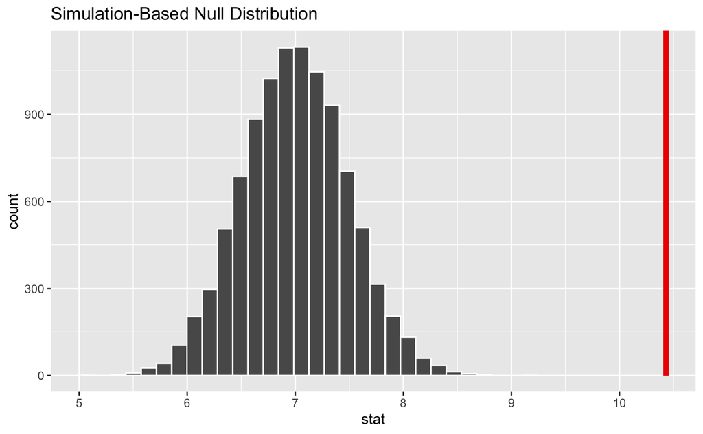

```r
null_distribution %>%
  visualise(bins = 30) +
  shade_p_value(obs_stat = observed_stat$mean_sleep_total, direction = "both")
```

```r
p_value <- null_distribution %>%
  get_p_value(obs_stat = observed_stat$mean_sleep_total, direction = "both")
```

```
Please be cautious in reporting a p-value of 0. This result is an approximation based on the number of `reps` chosen in the `generate()` step. See `?get_p_value()` for more information.
```

```r
p_value
```

| p_value |
| --- |
| 0 |

As p value is almost 0 which means that there is a statistically significant difference between mean total sleep and 7. We reject the null hypothesis.

The p-value is below α and so we reject H0 and conclude that the mean sleep_total in the sampled population of animal types differs significantly from the value of 7 hours typical of jabberwockies.

Perform an appropriate statistical test to determine whether omnivores sleep for significantly longer than herbivores, on average.

alpha = 0.05

H0: omnivore_sleep - herbivore_sleep = 0 Ha: omnivore_sleep - herbivore_sleep > 0

[output not shown]

[output cut: 42 more lines]

[output not shown]

[output cut: 990 more lines]

```r
observed_stat <- omni_herb %>%
  specify(response = sleep_total, explanatory = vore) %>%
  calculate(stat = "diff in means", order = c("omni", "herbi"))

observed_stat
```

| stat |
| --- |
| 1.415625 |

[figure not shown]

```r
null_distribution %>%
  get_p_value(obs_stat = observed_stat, direction = "right")
```

| p_value |
| --- |
| 0.1258 |

P value is more than 0.05 which means that we fail to reject the null hypothesis and did not find significant difference in total_sleep between omni and herbi.

The p-value is equal to or greater than α, and so we fail to reject H0. There is insufficient evidence to conclude that omnivores sleep for significantly longer than herbivores on average.

Perform an appropriate statistical test to determine whether the proportion of domesticated animal types in the population of animal types is greater than 5%.

H0: prop_dom = 5% Ha: prop_dom > 5%

```r
prop_dom <- msleep %>%
  mutate(is_domesticated = if_else(conservation == "domesticated", "1", "0")) %>%
  mutate(is_domesticated = replace_na(is_domesticated, "0"))

prop_dom
```

| name | genus | vore | order | conservation | sleep_total | sleep_rem | sleep_cycle | awake | brainwt | bodywt | is_domesticated |
| --- | --- | --- | --- | --- | --- | --- | --- | --- | --- | --- | --- |
| Cheetah | Acinonyx | carni | Carnivora | lc | 12.1 | NA | NA | 11.90 | NA | 50.000 | 0 |
| Owl monkey | Aotus | omni | Primates | NA | 17.0 | 1.8 | NA | 7.00 | 0.01550 | 0.480 | 0 |
| Mountain beaver | Aplodontia | herbi | Rodentia | nt | 14.4 | 2.4 | NA | 9.60 | NA | 1.350 | 0 |
| Greater short-tailed shrew | Blarina | omni | Soricomorpha | lc | 14.9 | 2.3 | 0.1333333 | 9.10 | 0.00029 | 0.019 | 0 |
| Cow | Bos | herbi | Artiodactyla | domesticated | 4.0 | 0.7 | 0.6666667 | 20.00 | 0.42300 | 600.000 | 1 |
| Three-toed sloth | Bradypus | herbi | Pilosa | NA | 14.4 | 2.2 | 0.7666667 | 9.60 | NA | 3.850 | 0 |
| Northern fur seal | Callorhinus | carni | Carnivora | vu | 8.7 | 1.4 | 0.3833333 | 15.30 | NA | 20.490 | 0 |
| Vesper mouse | Calomys | NA | Rodentia | NA | 7.0 | NA | NA | 17.00 | NA | 0.045 | 0 |
| Dog | Canis | carni | Carnivora | domesticated | 10.1 | 2.9 | 0.3333333 | 13.90 | 0.07000 | 14.000 | 1 |
| Roe deer | Capreolus | herbi | Artiodactyla | lc | 3.0 | NA | NA | 21.00 | 0.09820 | 14.800 | 0 |

[output cut: 73 more lines]

```r
null_distribution <- prop_dom %>%
  specify(response = is_domesticated, success = "1") %>%
  hypothesise(null = "point", p = 0.05) %>%
  generate(reps = 10000, type = "simulate") %>%
  calculate(stat = "prop")

null_distribution
```

| replicate | stat |
| --- | --- |
| 1 | 0.07228916 |
| 2 | 0.03614458 |
| 3 | 0.02409639 |
| 4 | 0.12048193 |
| 5 | 0.06024096 |
| 6 | 0.06024096 |
| 7 | 0.07228916 |
| 8 | 0.02409639 |
| 9 | 0.06024096 |
| 10 | 0.13253012 |

[output cut: 990 more lines]

```r
observed_stat <- prop_dom %>%
  specify(response = is_domesticated, success = "1")  %>%
  calculate(stat = "prop")

observed_stat
```

| stat |
| --- |
| 0.1204819 |

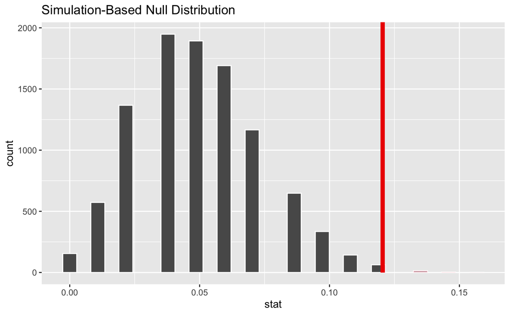

```r
null_distribution %>%
  visualise(bins = 30) +
  shade_p_value(obs_stat = observed_stat, direction = "greater")
```

```r
null_distribution %>%
  get_p_value(obs_stat = observed_stat, direction = "greater")
```

| p_value |
| --- |
| 0.0081 |

P value is below 0.05 which means that there is a statistically significant proportion in domesticated and animals which is more than 5%. We reject the null hypothesis.

The p-value is less than α, so we reject H0 and accept that the proportion of domesticated animal types in the data is significantly greater than 5%.

1. You work for a independent coffee shop. You’ve performed a small survey in the local town and found that 40% of the people you randomly asked were aware of your shop in the town. You then conduct a marketing campaign by flyering local venues and targeting advertisements on social media. Finally you conduct a second small random survey in the town, asking if people are aware of your coffee shop. You want to test the hypothesis that the campaign has significantly increased awareness of the shop.

H0: prop_campaign = 40% Ha: prop_campaign > 40%

This will be a proportion test of people knowing the coffee shop so I would use a simulation test for it. I want to test here if the proportion of people who knows the shop has increased after the campaign. So I would use a one sample proportion test, right sided.Null hypothesis is nothing changed after the campaign and still 40% aware of the shop. Alternative hypothesis is that people proportion increased significantly.

2. You work for a website design company and have performed an A/B test on the position of a banner on a website page promoting a particular item.

In the current test, the first group continues to be shown the banner at the right hand side of the webpage (its usual position) while the test group is shown it at the top of the page. The performance metric we will be testing is click through rate (CTR) on the banner, i.e. what proportion of users click on the banner

H0: CTR(unchanged) - CTR(changed) = 0 Ha: CTR(unchanged) - CTR(changed) != 0

3. You work as an analyst for a car manufacturing company - they have specific standards they must meet for standards and regulation purposes. You have been asked to check the quality control of the manufacture of a particular car part. The part must have a width of 145mm, with a small (given) level of tolerance. You have been given data on a sample of 1,000 parts produced over the period of a week.

H0: car_width = 145 mm Ha: car_width != 145 mm

This will be a one sample mean test and I would use a bootstrap test for it. I want to test here car width is different of what it should be or not (over 1000 samples). Two sided test. Null hypothesis is there is no difference in car_width and reality stays the same. Alternative hypothesis is that there are 1000 parts with significant different width.

Coffee shop problem. Significance level: 0.05, calculated p-value: 0.07

Null hypothesis is failed to be rejected and reality stays the same. There is no evidence of significant increase in prop of people knowing the shop after the campaign. Or it might be that there is no enough evidence to say that the proportion has increased.

Website company problem. Significance level: 0.01, p-value: 0.006 P value is very small so there is a significant difference in CTR for changed banner, therefore I reject the null hypothesis in favour of alternative hypothesis.

Manufacturing company problem. Significance level: 0.05, p-value: 0.55